# Clustering and Annotation

Huaying Qiu

2024-03-21

## Introduction

In this tutorial, we will go through how to cluster and annotation single cell proteomics data, using Phenograph. Here, I will use data from our INDEPTH study as an example. Some details of the code may need to be changed for application to data from other projects, but the idea is easily transferable.

## Library

Here are the libraries needed:

- `tidyverse` contains functions we need to clean and manipulate our dataframe.
- `matrixStats` contains functions we need to transform our protein marker intensity to $[0,1]$.
- `Rphenoannoy` contains functions to run Phenograph.
- `ComplexHeatmap` contains functions we need to plot the marker enrichment heatmap for clusters.
- `Rcpp` contains some C++ functions that Phenograph needs.

```r
library(tidyverse)
library(matrixStats)
library(Rphenoannoy)
library(ComplexHeatmap)
library(Rcpp)
```

## Load data

Here we will load our data and take a look at its summary statistics.

```r
df <- read_csv('~/INDEPTH/run_031124/extracted_info/L24_dataScaleSize.csv')

source('./util.R')

summary(df)
```

```
##    cellLabel          Y_cent            X_cent         cellSize
##  Min.   :     1   Min.   :  703.4   Min.   : 2875   Min.   :  15.0
##  1st Qu.:204508   1st Qu.: 6401.5   1st Qu.:10475   1st Qu.: 148.0
##  Median :409016   Median : 8889.8   Median :15083   Median : 206.0
##  Mean   :409016   Mean   : 8692.8   Mean   :15214   Mean   : 216.6
##  3rd Qu.:613524   3rd Qu.:11129.7   3rd Qu.:20019   3rd Qu.: 270.0
##  Max.   :818031   Max.   :17221.5   Max.   :27835   Max.   :3952.0
##       DAPI             CD11b              CD68              CD11c
##  Min.   :  2.319   Min.   :0.00000   Min.   :  0.0000   Min.   : 0.00000
##  1st Qu.: 88.945   1st Qu.:0.00000   1st Qu.:  0.0000   1st Qu.: 0.00000
##  Median :118.509   Median :0.00000   Median :  0.2662   Median : 0.05376
##  Mean   :116.857   Mean   :0.05613   Mean   :  7.4932   Mean   : 0.40609
##  3rd Qu.:145.664   3rd Qu.:0.02532   3rd Qu.:  5.7432   3rd Qu.: 0.38194
##  Max.   :255.000   Max.   :1.00000   Max.   :255.0000   Max.   :31.99697
##       Pax5              CD20             BCL6               CD8
##  Min.   : 0.0000   Min.   :  0.00   Min.   :  0.0000   Min.   : 0.00000
##  1st Qu.: 0.6129   1st Qu.: 19.02   1st Qu.:  0.0000   1st Qu.: 0.03409
##  Median : 3.0105   Median : 36.45   Median :  0.0000   Median : 0.15825
##  Mean   : 4.8793   Mean   : 38.97   Mean   :  1.0647   Mean   : 1.38406
##  3rd Qu.: 8.3176   3rd Qu.: 55.72   3rd Qu.:  0.1577   3rd Qu.: 1.22443
##  Max.   :55.1091   Max.   :255.00   Max.   :145.2703   Max.   :74.21505
##      CD163                CD4              FoxP3               CD31
##  Min.   :  0.00000   Min.   :  0.000   Min.   : 0.00000   Min.   :  0.000
##  1st Qu.:  0.01887   1st Qu.:  4.119   1st Qu.: 0.03191   1st Qu.:  0.806
##  Median :  0.11258   Median :  6.323   Median : 0.08889   Median :  1.779
##  Mean   :  1.14629   Mean   :  6.714   Mean   : 0.17335   Mean   :  4.188
##  3rd Qu.:  0.61878   3rd Qu.:  8.926   3rd Qu.: 0.21901   3rd Qu.:  3.406
##  Max.   :224.15000   Max.   :194.064   Max.   :16.26061   Max.   :255.000
##       CD3
##  Min.   :0.00000
##  1st Qu.:0.00565
##  Median :0.26974
##  Mean   :0.40751
##  3rd Qu.:0.85345
##  Max.   :1.00000
```

## Transform data

Next, we will transform all markers to be within the range of $[0,1]$.

```r
# create a new dataframe
df_trans <- df

# getting the 0 and 99.9 percentile of each marker
rng <- colQuantiles(as.matrix(df[,5:17]), probs = c(0, 0.999))

# quantile normalization
expr <- t((t(as.matrix(df[,5:17]))-rng[,1]) / (rng[,2]-rng[,1]))

# truncate lower end at 0
expr[expr < 0] <- 0

# truncate upper end at 1
expr[expr > 1] <- 1

# overwrite the markers with transformed markers
df_trans[,5:17] <- expr
```

Now all markers are within the range of $[0,1]$

```r
summary(df_trans[,5:17])
```

```
##       DAPI            CD11b              CD68              CD11c
##  Min.   :0.0000   Min.   :0.00000   Min.   :0.000000   Min.   :0.000000
##  1st Qu.:0.3635   1st Qu.:0.00000   1st Qu.:0.000000   1st Qu.:0.000000
##  Median :0.4875   Median :0.00000   Median :0.001139   Median :0.005995
##  Mean   :0.4806   Mean   :0.05623   Mean   :0.032016   Mean   :0.045001
##  3rd Qu.:0.6015   3rd Qu.:0.02536   3rd Qu.:0.024575   3rd Qu.:0.042587
##  Max.   :1.0000   Max.   :1.00000   Max.   :1.000000   Max.   :1.000000
##       Pax5              CD20             BCL6               CD8
##  Min.   :0.00000   Min.   :0.0000   Min.   :0.000000   Min.   :0.000000
##  1st Qu.:0.02792   1st Qu.:0.1344   1st Qu.:0.000000   1st Qu.:0.001715
##  Median :0.13715   Median :0.2576   Median :0.000000   Median :0.007962
##  Mean   :0.22218   Mean   :0.2753   Mean   :0.039535   Mean   :0.069489
##  3rd Qu.:0.37893   3rd Qu.:0.3938   3rd Qu.:0.005891   3rd Qu.:0.061603
##  Max.   :1.00000   Max.   :1.0000   Max.   :1.000000   Max.   :1.000000
##      CD163                CD4             FoxP3               CD31
##  Min.   :0.0000000   Min.   :0.0000   Min.   :0.000000   Min.   :0.00000
##  1st Qu.:0.0004571   1st Qu.:0.1775   1st Qu.:0.009107   1st Qu.:0.00772
##  Median :0.0027274   Median :0.2724   Median :0.025366   Median :0.01704
##  Mean   :0.0274001   Mean   :0.2890   Mean   :0.049138   Mean   :0.03989
##  3rd Qu.:0.0149906   3rd Qu.:0.3845   3rd Qu.:0.062497   3rd Qu.:0.03262
##  Max.   :1.0000000   Max.   :1.0000   Max.   :1.000000   Max.   :1.00000
##       CD3
##  Min.   :0.00000
##  1st Qu.:0.00565
##  Median :0.26974
##  Mean   :0.40751
##  3rd Qu.:0.85345
##  Max.   :1.00000
```

## Clustering

Now, we can start to cluster our data. Always set a random seed to make sure that our results are reproducible. Time needed for clustering is dependent on the size of your data and the $k$ you set. For demostration purposes, we will just randomly sample 10000 rows from the full dataset and the clusters will be randomly annotated.

```r
# Since CD4 is not really working in this imaging run, we will not use it for clustering.
# DAPI is usually not used for clustering either.

df_trans_filter <- df_trans %>%
  dplyr::select(cellLabel, 5:17) %>%
  dplyr::select(-CD4, -DAPI) %>%
  sample_n(10000)

# Cluster

cluster_result <- to_cluster(df_trans_filter, 'cellLabel', colnames(df_trans_filter[,2:12]), 45, 123, z = FALSE)
```

```
## Run Rphenograph starts:
##   -Input data of 10000 rows and 11 columns
##   -k is set to 45
```

```
##   Finding nearest neighbors...DONE ~ 6.525 s
##   Compute jaccard coefficient between nearest-neighbor sets...
```

```
## Presorting knn...
```

```
## presorting DONE ~ 0.316 s
##   Start jaccard
## DONE ~ 0.048 s
##   Build undirected graph from the weighted links...DONE ~ 0.15 s
##   Run louvain clustering on the graph ...DONE ~ 0.743 s
```

```
## Run Rphenograph DONE, totally takes 7.46599999999997s.
```

```
##   Return a community class
##   -Modularity value: 0.8305062
##   -Number of clusters: 21
```

[output not shown]

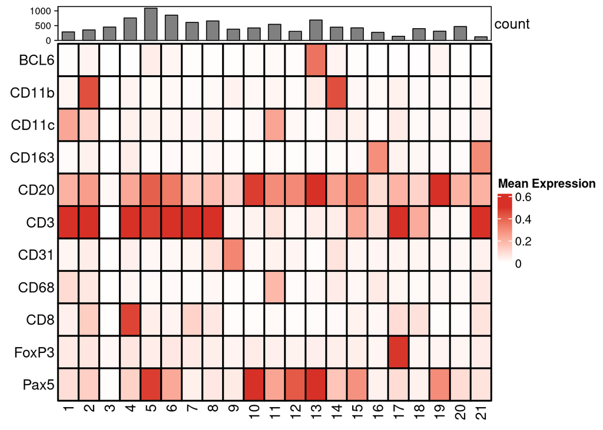

Here is a summary of the dataset with the cluster column.

```r
summary(cluster_result)
```

```
##    cellLabel          CD11b              CD68              CD11c
##  Min.   :   183   Min.   :0.00000   Min.   :0.000000   Min.   :0.000000
##  1st Qu.:208756   1st Qu.:0.00000   1st Qu.:0.000000   1st Qu.:0.000000
##  Median :415300   Median :0.00000   Median :0.001079   Median :0.006195
##  Mean   :412744   Mean   :0.05421   Mean   :0.031059   Mean   :0.045343
##  3rd Qu.:614885   3rd Qu.:0.02424   3rd Qu.:0.023460   3rd Qu.:0.044230
##  Max.   :817929   Max.   :1.00000   Max.   :1.000000   Max.   :1.000000
##
##       Pax5              CD20             BCL6               CD8
##  Min.   :0.00000   Min.   :0.0000   Min.   :0.000000   Min.   :0.000000
##  1st Qu.:0.02847   1st Qu.:0.1342   1st Qu.:0.000000   1st Qu.:0.001650
##  Median :0.13645   Median :0.2595   Median :0.000000   Median :0.007368
##  Mean   :0.22352   Mean   :0.2758   Mean   :0.038754   Mean   :0.069681
##  3rd Qu.:0.38295   3rd Qu.:0.3932   3rd Qu.:0.005352   3rd Qu.:0.059970
##  Max.   :1.00000   Max.   :1.0000   Max.   :1.000000   Max.   :1.000000
##
##      CD163              FoxP3               CD31               CD3
##  Min.   :0.000000   Min.   :0.000000   Min.   :0.000000   Min.   :0.000000
##  1st Qu.:0.000476   1st Qu.:0.008946   1st Qu.:0.007919   1st Qu.:0.006206
##  Median :0.002795   Median :0.024769   Median :0.017376   Median :0.283880
##  Mean   :0.026885   Mean   :0.049255   Mean   :0.039790   Mean   :0.413105
##  3rd Qu.:0.014693   3rd Qu.:0.062127   3rd Qu.:0.032451   3rd Qu.:0.860780
##  Max.   :1.000000   Max.   :1.000000   Max.   :1.000000   Max.   :1.000000
##
##    pg_cluster
##  5      :1092
##  6      : 856
##  4      : 761
##  13     : 691
##  8      : 659
##  7      : 609
##  (Other):5332
```

### Write results for view in mantis

Now that we have the clusters and we have matched them to the cell labels, we can output a dataset to be read in [Mantis-Viewer](https://github.com/CANDELbio/mantis-viewer) for visual inspection.

```r
mantis_df <- cluster_result %>%
  dplyr::select(cellLabel, pg_cluster) %>%
  mutate(core_name = rep('core1', nrow(df_trans_filter))) %>%
  dplyr::select(core_name, cellLabel, pg_cluster)

head(mantis_df)
```

```
## # A tibble: 6 × 3
##   core_name cellLabel pg_cluster
##   <chr>         <dbl> <fct>
## 1 core1        744796 1
## 2 core1        453241 2
## 3 core1        414263 3
## 4 core1        525496 4
## 5 core1        367902 5
## 6 core1         25211 6
```

```r
#write_csv(mantis_df, 'path', headers = FALSE)
```

### Sub-cluster

Sub-clustering strategy:

1. Set aside clusters that you know the cell type already. Save into a dataframe
2. Split the rest of data into different sub-clustering tasks.
3. Cluster each of those sub-dataframe.
4. Annotate.
5. Join the data back with full join.

```r
annotated_cells <- cluster_result %>%
  dplyr::filter(pg_cluster %in% c(1:10))

mixture1 <- cluster_result %>%
  dplyr::filter(pg_cluster %in% c(11:15))

mixture2 <- cluster_result %>%
  dplyr::filter(pg_cluster %in% c(16:20))
```

Here we will sub-cluster mixture1 as an example.

```r
sub_cluster_result <- to_cluster(mixture1, 'cellLabel', c('Pax5', 'CD163', 'CD68'), 45, 123, z = FALSE)
```

```
## Run Rphenograph starts:
##   -Input data of 2415 rows and 3 columns
##   -k is set to 45
```

```
##   Finding nearest neighbors...DONE ~ 0.555 s
##   Compute jaccard coefficient between nearest-neighbor sets...
```

```
## Presorting knn...
```

```
## presorting DONE ~ 0.068 s
##   Start jaccard
## DONE ~ 0.016 s
##   Build undirected graph from the weighted links...DONE ~ 0.048 s
##   Run louvain clustering on the graph ...DONE ~ 0.067 s
```

```
## Run Rphenograph DONE, totally takes 0.685999999999993s.
```

```
##   Return a community class
##   -Modularity value: 0.8594803
##   -Number of clusters: 16
```

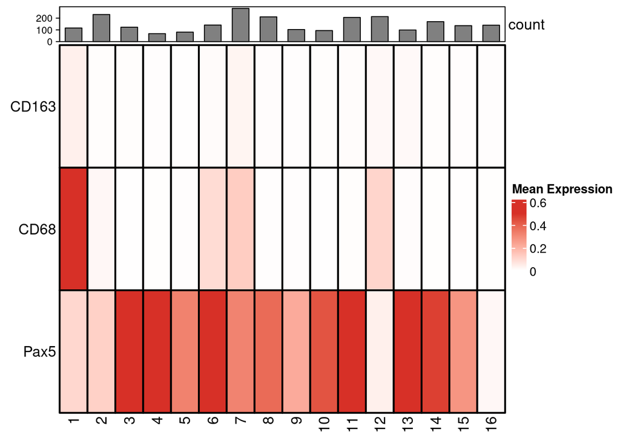

And we can again write it into a csv for view in Mantis-Viewer.

```r
mantis_df <- sub_cluster_result %>%
  dplyr::select(cellLabel, pg_cluster) %>%
  mutate(core_name = rep('core1', nrow(sub_cluster_result))) %>%
  dplyr::select(core_name, cellLabel, pg_cluster)

head(mantis_df)
```

```
## # A tibble: 6 × 3
##   core_name cellLabel pg_cluster
##   <chr>         <dbl> <fct>
## 1 core1        767317 1
## 2 core1        104821 2
## 3 core1        284630 3
## 4 core1        172186 4
## 5 core1        251701 5
## 6 core1        566996 1
```

```r
#write_csv(mantis_df, 'path', headers = FALSE)
```

If the resulting cluster is clear, we can assign annotations to each cluster.

```r
mixture1_annotation <- sub_cluster_result %>%
  mutate(Annotation = case_when(pg_cluster %in% c(1:5, 7:15, 17:19) ~ 'M1',
                                pg_cluster == 6 ~ 'Other',
                                pg_cluster == 16 ~ 'BCL6- B Cell'))
```

The above procedure is iteratively repeated for each mixture until a satisfactory annotation is achieved. At the end, you will just need to `dplyr::full_join` each of your annoated dataframe together to get the full annotation. Note that each of the dataframe generated in each sub-clustering run should be mutually exclusive, i.e., cell 1 can only be in one of your annotated dataframe.